# Nobel Laureates Data Analysis

## Step I: Understnding the problem statement

The goal of this is to analyse the Nobel Laureates dataset to gain insight into their lives, demographics and categories they were awarded for

## Step II: Understanding the dataset

The dataset contains details about their names, gender, where and when they were born, where and they died, whch unversity they studied in, the category they got the Nobel Prize for and when and lastly their motivation to do so.

## Step III: Importing the dataset

We load the datset into a pandas dataframe and to help us easily make insights, understand trends and visualise them using the Matplotlib library. For this we read the CSV and upload the data to a Pandas datset.

## Step IV: Data Exploration, Selection, Cleaning

We try to identify duplicate rows, with Null values and remove them.

## Step V: Data Analysis and Visualisation

We try to brainstorm and answer questions about this dataset and see trends into it and see which might help with visualisation will make it clear.

## Questions Answered

Q1. The count of laureates in each category ?  
Q2. The distribution of laureates by gender ?  
Q3. How many laureates might have had foreign education ?  
Q4. How many laureates died abroad ?  
Q5. Which university produced the most Nobel laureates ?  
Q6. In which country were the most Nobel laureates born ?  
Q7. How many Nobel Laureates were awarded the Nobel Prize posthumously ?  
Q8. The average lifespan of Nobel Laureates ?  
Q9. What are the most common first names of Nobel Laureates ?

```python
import pandas as pd
import matplotlib.pyplot as plt
import numpy as np
```

```python
df = pd.read_csv('export.csv')
```

```python
df.drop_duplicates(inplace=True)
```

```python
print(df.columns)
```

```
Index(['id', 'firstname', 'surname', 'born', 'died', 'bornCountry',
       'bornCountryCode', 'bornCity', 'diedCountry', 'diedCountryCode',
       'diedCity', 'gender', 'year', 'category', 'overallMotivation', 'share',
       'motivation', 'name', 'city', 'country'],
      dtype='object')
```

```python
print(df.head(5))
```

```
   id       firstname    surname        born        died  \
0   1  Wilhelm Conrad    Röntgen  1845-03-27  1923-02-10
1   2      Hendrik A.    Lorentz  1853-07-18  1928-02-04
2   3          Pieter     Zeeman  1865-05-25  1943-10-09
3   4           Henri  Becquerel  1852-12-15  1908-08-25
4   5          Pierre      Curie  1859-05-15  1906-04-19

             bornCountry bornCountryCode                bornCity  \
0  Prussia (now Germany)              DE  Lennep (now Remscheid)
1        the Netherlands              NL                  Arnhem
2        the Netherlands              NL              Zonnemaire
3                 France              FR                   Paris
4                 France              FR                   Paris

       diedCountry diedCountryCode   diedCity gender  year category  \
```

[output cut: 26 more lines]

```python
print(df.tail(5))
```

```
       id firstname    surname        born        died        bornCountry  \
995  1030     Louis       Brus  1943-00-00  0000-00-00                USA
996  1031   Aleksey    Yekimov  1945-00-00  0000-00-00  USSR (now Russia)
997  1032       Jon      Fosse  1959-09-29  0000-00-00             Norway
998  1033    Narges  Mohammadi  1972-04-21  0000-00-00               Iran
999  1034   Claudia     Goldin  1946-00-00  0000-00-00                USA

    bornCountryCode      bornCity diedCountry diedCountryCode diedCity  \
995              US  Cleveland OH         NaN             NaN      NaN
996              RU           NaN         NaN             NaN      NaN
997              NO     Haugesund         NaN             NaN      NaN
998              IR        Zanjan         NaN             NaN      NaN
999              US   New York NY         NaN             NaN      NaN

     gender  year    category overallMotivation  share  \
```

[output cut: 19 more lines]

```python
print(df.shape)
```

```
(1000, 20)
```

```python
result = df.groupby('category')['id'].count().reset_index(name='count')
print(result)
```

```
     category  count
0   chemistry    194
1   economics     93
2  literature    120
3    medicine    227
4       peace    141
5     physics    225
```

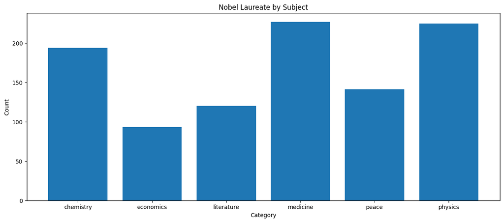

```python
plt.figure(figsize=(15,6))
plt.bar(result['category'],result['count'])
plt.title('Nobel Laureate by Subject')
plt.xlabel('Category')
plt.ylabel('Count')
plt.show()
```

```python
column1='bornCountry'
column2='country'
foreign_education=(df['bornCountry']!=df['country']).sum()
print(foreign_education)
```

```
521
```

```python
result2=df.groupby('gender')['id'].count().reset_index(name='count')
print(result2)
```

```
   gender  count
0  female     65
1    male    905
2     org     30
```

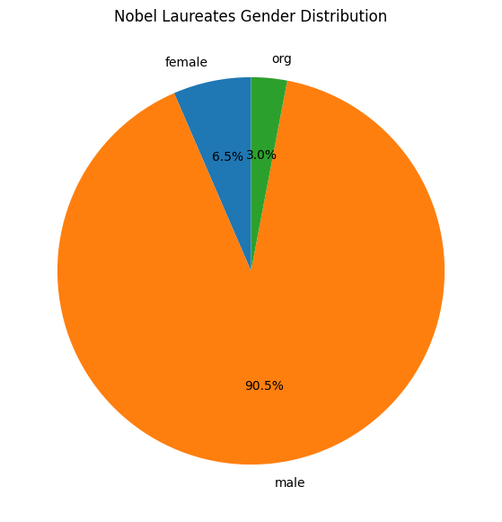

```python
plt.figure(figsize=(15,7))
plt.pie(result2['count'], labels=result2['gender'], autopct='%1.1f%%', startangle=90)
plt.title('Nobel Laureates Gender Distribution')
plt.show()
```

```python
foreign_death = (df['bornCountry'] != df['diedCountry']).sum()
print(foreign_death)
```

```
602
```

```python
uc = df['name'].value_counts()
most_laureates_university = uc.idxmax()
print(f"The university with the most Nobel laureates is: {most_laureates_university}")
```

```
The university with the most Nobel laureates is: University of California
```

```python
university_counts=df.groupby('name')['id'].count().reset_index(name='count')
university_counts = university_counts.sort_values(by='count', ascending=False)
print(university_counts)
```

```
                                                  name  count
243                           University of California     36
71                                  Harvard University     28
136        Massachusetts Institute of Technology (MIT)     22
210                                Stanford University     22
247                              University of Chicago     19
..                                                 ...    ...
137  Massachusetts Institute of Technology (MIT) Ce...      1
138     Max Planck Institute for Biophysical Chemistry      1
139  Max Planck Institute for Evolutionary Anthropo...      1
140  Max Planck Institute for Extraterrestrial Physics      1
321  École municipale de physique et de chimie indu...      1

[322 rows x 2 columns]
```

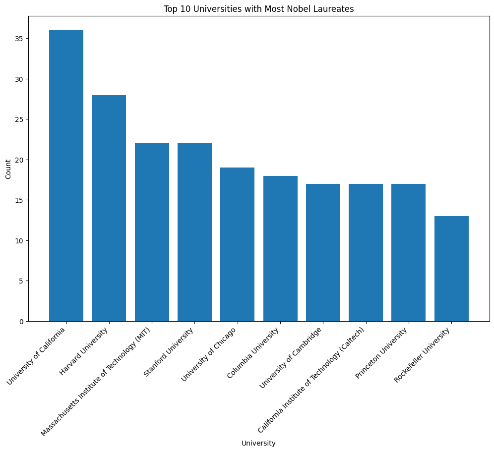

```python
plt.figure(figsize=(12, 8))
plt.bar(university_counts['name'][:10], university_counts['count'][:10])
plt.title('Top 10 Universities with Most Nobel Laureates')
plt.xlabel('University')
plt.ylabel('Count')
plt.xticks(rotation=45, ha='right')
plt.show()
```

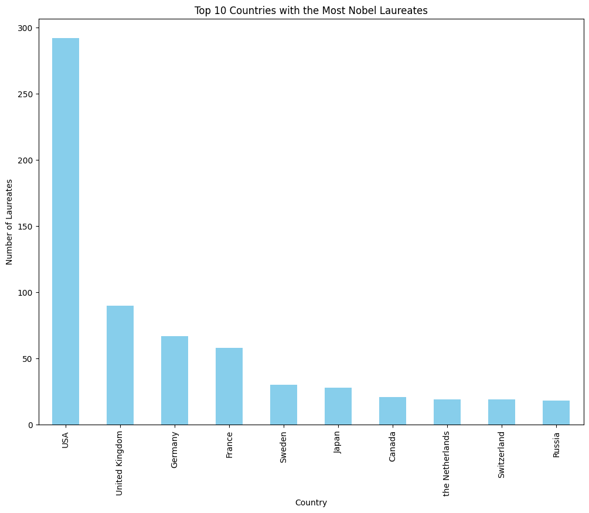

```python
laureates_by_country = df['bornCountry'].value_counts()
most_laureates_country = laureates_by_country.idxmax()
most_laureates_count = laureates_by_country.max()
plt.figure(figsize=(12, 9))
laureates_by_country.head(10).plot(kind='bar', color='skyblue')
plt.title('Top 10 Countries with the Most Nobel Laureates')
plt.xlabel('Country')
plt.ylabel('Number of Laureates')
plt.show()
```

```python
df['died'] = pd.to_datetime(df['died'], errors='coerce')
posthumous_laureates = df[df['died'].isnull()]
num_posthumous_laureates = len(posthumous_laureates)
print(num_posthumous_laureates)
```

```
335
```

```python
df['born'] = pd.to_datetime(df['born'], errors='coerce')
df['died'] = pd.to_datetime(df['died'], errors='coerce')
df['lifespan'] = df['died'] - df['born']
valid_lifespan_data = df.dropna(subset=['born', 'died', 'lifespan'])
average_lifespan = valid_lifespan_data['lifespan'].mean()
print(average_lifespan)
```

```
29528 days 07:46:15.903614464
```

```python
first_names = df['firstname'].str.split()
df['first_name'] = first_names.apply(lambda x: x[0] if x else None)
most_common_first_names = df['first_name'].value_counts().head(12)
print(most_common_first_names)
```

```
first_name
John       28
Robert     27
Sir        24
William    18
Paul       18
George     18
Richard    15
James      14
Peter      10
David      10
Charles    10
Albert      9
Name: count, dtype: int64
```